# Newsvendor Simulation

Steven Shechter

### Overview:

This example simulates and analyzes the Newsvendor Problem. There is a related Shiny version of this model in Newsvendor_app.R

*Note: there are several chunks of R code that aren’t useful to display in this report, so they don’t appear here, but they does appear in the .Rmd file. For example, I hide the R code that creates functions, initialization of some variables, etc. It’s not particularly interesting for the reader of this report. One can dig into the .Rmd file itself for this.*

### Model inputs:

The key model inputs of the Newsvendor problem are:

- Purchase cost
- Resale price
- Demand distribution

For this model, we will assume the demand is Uniformly distributed between [minU, maxU]. (the Shiny version lets the user also consider a Normal distribution) We will also set the number of simulation replications and the random number seed in the following code chunk. By fixing the random number seed, we are able to replicate the simulation results shown in this report each time:

```r
purchase_cost <- 0.25
sale_price <- 1
minU <- 100
maxU <- 200

reps <- 5000
set.seed(1)
```

### Evaluating a specific order quantity:

First, we will run simulations and analysis on a specific order quantity. Later, we will search for an optimal order quantity.

```r
order_q <- 175  # change this to whatever order quantity you want to evaluate
```

Showing the average profit performance as well as the entire histogram of profits across the simulation replications:

```
## [1] "The average profit (and 95% CI half-width) associted with order_q = 175 is: 102.66 +/- 0.70 "
```

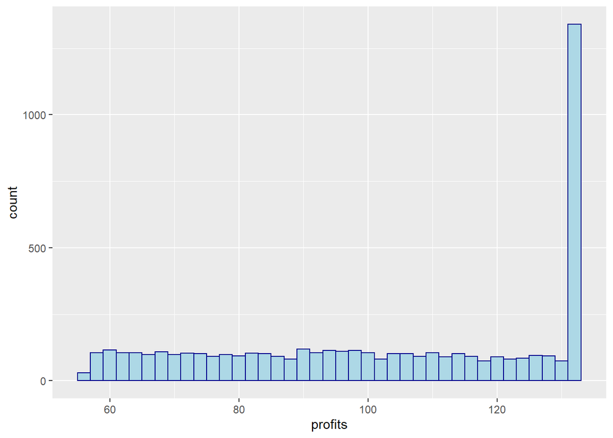

### Evaluate several order quantities:

The code will evaluate order quantites from 100 to 200 in increments spaced 1/20 of the distance between the two. It will identify the order quantity among these that yields the best (sample) average profit, and plot all of the averages and the +/- 95% confidence interval band.

```
## [1] "The average profit maximizing order quantity is: 180"
```

```
## [1] "The average profit (and 95% CI half-width) from this is: 103.10 +/- 0.73"
```

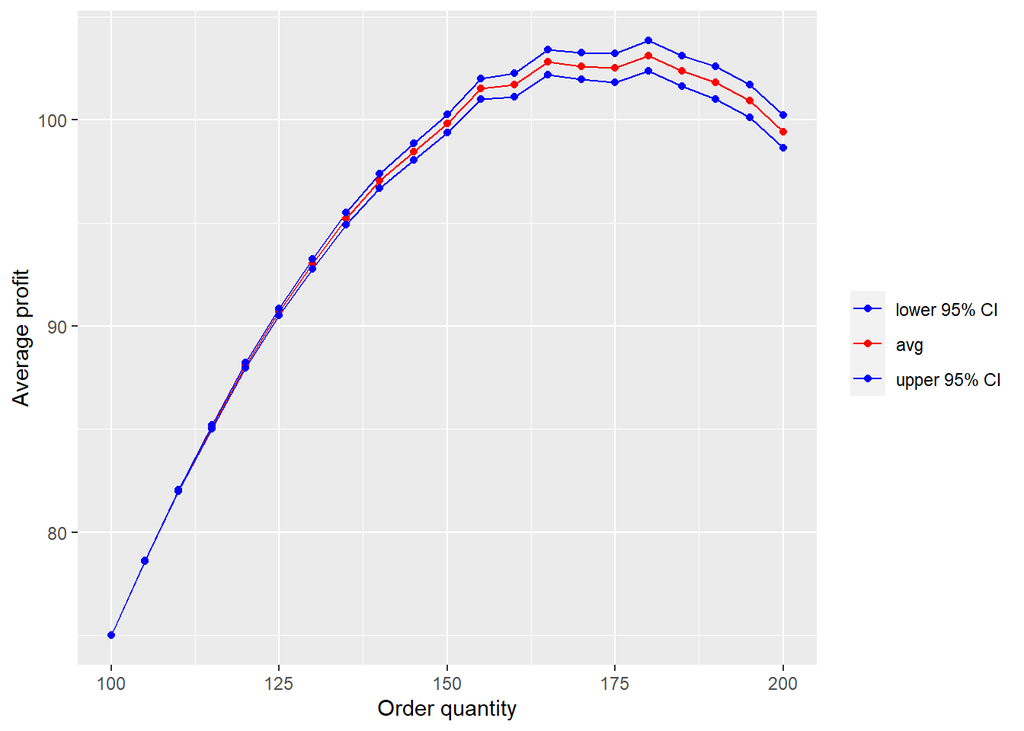